# Data Quality Check Report

Insitute for Alpine Environment, Eurac Research

Report start at **2017-12-13 11:52:47**

### INPUT info:

File selected: **P2.dat**

You have also select these parameters:

- Data start from row: *5*
- The name of column is on row: *2*
- The datetime header is: *TIMESTAMP*
- The record header is: *RECORD*
- The datetime format is: *yyyy-mm-dd HH:MM*
- The sampling interval is: *15 min*

The folders are:

- Data folder: *H:/Projekte/Klimawandel/Experiment/data/2order/DQC_BrC_test_data/*
- Report folder: *H:/Projekte/Klimawandel/Experiment/data/2order/DataQualityCheckEuracAlpEnv/Report/*
- Output folder: *H:/Projekte/Klimawandel/Experiment/data/2order/DQC_BrC_test_data/test_output/*
- Support folder: *H:/Projekte/Klimawandel/Experiment/data/2order/DataQualityCheckEuracAlpEnv/Data/Support_files/*

Range file in support folder is called: *Range.csv*

You decide: *to write output file in output folder*

### OUTPUT:

#### Info empty file:

P2.dat has some obseravtion.

#### **Duplicated rows**

More details on: H:/Projekte/Klimawandel/Experiment/data/2order/DQC_BrC_test_data/test_output/Duplicated_P2.csv

#### **Overlap**

In P2.dat there isn’t any overlap!

#### **Missing dates**

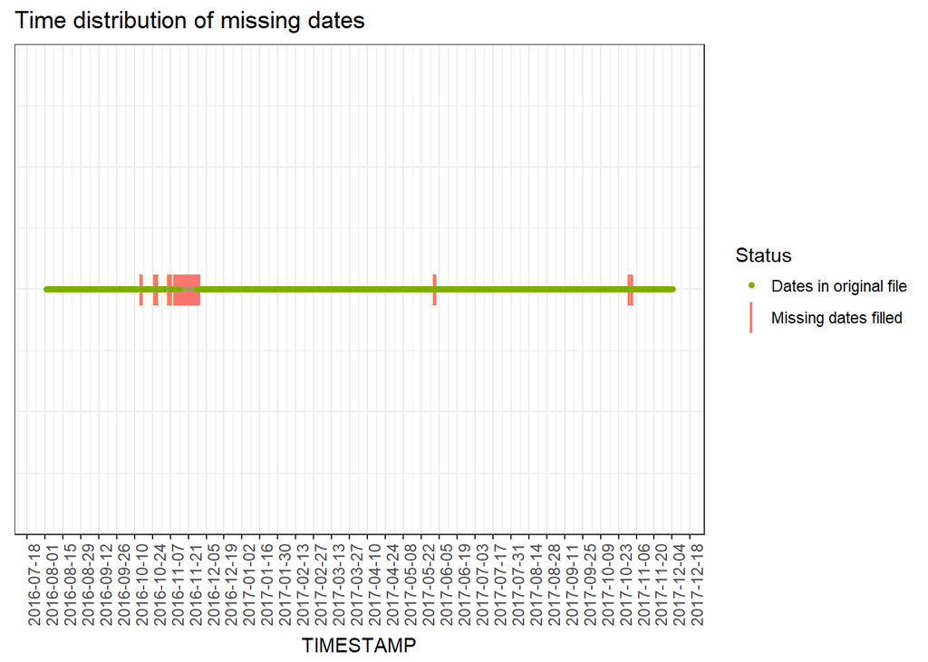

Statistics of missing dates:

| From | To | Number of Record |
| --- | --- | --- |
| 2016-10-15 01:15:00 | 2016-10-15 07:15:00 | 25 |
| 2016-10-25 18:00:00 | 2016-10-26 08:45:00 | 60 |
| 2016-10-26 15:45:00 | 2016-10-26 15:45:00 | 1 |
| 2016-10-26 16:30:00 | 2016-10-27 08:15:00 | 64 |
| 2016-11-05 10:00:00 | 2016-11-05 10:00:00 | 1 |
| 2016-11-05 14:45:00 | 2016-11-06 09:30:00 | 76 |
| 2016-11-06 10:15:00 | 2016-11-06 12:15:00 | 9 |
| 2016-11-06 12:45:00 | 2016-11-06 13:45:00 | 5 |
| 2016-11-06 14:45:00 | 2016-11-07 08:00:00 | 70 |
| 2016-11-10 06:45:00 | 2016-11-10 08:30:00 | 8 |
| 2016-11-11 06:30:00 | 2016-11-11 10:00:00 | 15 |
| 2016-11-12 02:15:00 | 2016-11-12 08:15:00 | 25 |
| 2016-11-13 06:00:00 | 2016-11-13 08:45:00 | 12 |
| 2016-11-14 02:45:00 | 2016-11-14 08:15:00 | 23 |
| 2016-11-15 05:30:00 | 2016-11-15 08:30:00 | 13 |
| 2016-11-16 06:15:00 | 2016-11-16 08:30:00 | 10 |
| 2016-11-17 05:45:00 | 2016-11-17 08:00:00 | 10 |
| 2016-11-18 06:00:00 | 2016-11-18 09:00:00 | 13 |
| 2016-11-18 09:45:00 | 2016-11-18 09:45:00 | 1 |
| 2016-11-18 16:00:00 | 2016-11-19 10:30:00 | 75 |
| 2016-11-19 11:00:00 | 2016-11-19 11:00:00 | 1 |
| 2016-11-19 11:30:00 | 2016-11-19 11:30:00 | 1 |
| 2016-11-19 12:00:00 | 2016-11-19 12:15:00 | 2 |
| 2016-11-19 12:45:00 | 2016-11-19 12:45:00 | 1 |
| 2016-11-19 13:15:00 | 2016-11-19 13:15:00 | 1 |
| 2016-11-19 13:45:00 | 2016-11-19 13:45:00 | 1 |
| 2016-11-19 14:30:00 | 2016-11-20 10:15:00 | 80 |
| 2016-11-20 12:30:00 | 2016-11-20 13:45:00 | 6 |
| 2016-11-20 14:45:00 | 2016-11-22 10:00:00 | 174 |
| 2016-11-22 10:45:00 | 2016-11-22 10:45:00 | 1 |
| 2016-11-22 11:15:00 | 2016-11-22 11:45:00 | 3 |
| 2016-11-22 12:15:00 | 2016-11-22 12:45:00 | 3 |
| 2016-11-22 13:15:00 | 2016-11-22 13:45:00 | 3 |
| 2016-11-22 14:15:00 | 2016-11-23 10:45:00 | 83 |
| 2016-11-23 11:15:00 | 2016-11-23 11:15:00 | 1 |
| 2016-11-23 12:30:00 | 2016-11-23 12:30:00 | 1 |
| 2016-11-23 13:00:00 | 2016-11-24 09:30:00 | 83 |
| 2016-11-24 10:00:00 | 2016-11-24 10:15:00 | 2 |
| 2016-11-24 10:45:00 | 2016-11-24 11:00:00 | 2 |
| 2016-11-24 11:30:00 | 2016-11-24 12:00:00 | 3 |
| 2016-11-24 13:30:00 | 2016-11-24 14:15:00 | 4 |
| 2016-11-24 15:00:00 | 2016-11-24 15:15:00 | 2 |
| 2016-11-24 15:45:00 | 2016-11-25 10:00:00 | 74 |
| 2016-11-25 10:30:00 | 2016-11-25 11:15:00 | 4 |
| 2016-11-25 11:45:00 | 2016-11-25 11:45:00 | 1 |
| 2016-11-25 12:45:00 | 2016-11-25 12:45:00 | 1 |
| 2016-11-25 13:30:00 | 2016-11-26 10:00:00 | 83 |
| 2016-11-26 10:30:00 | 2016-11-26 10:30:00 | 1 |
| 2016-11-26 15:15:00 | 2016-11-27 09:00:00 | 72 |
| 2016-11-29 07:45:00 | 2016-11-29 09:15:00 | 7 |
| 2016-11-29 10:30:00 | 2016-11-29 10:30:00 | 1 |
| 2017-06-01 10:00:00 | 2017-06-01 14:30:00 | 19 |
| 2017-06-01 15:00:00 | 2017-06-01 15:00:00 | 1 |
| 2017-10-31 09:15:00 | 2017-10-31 09:15:00 | 1 |
| 2017-11-02 07:15:00 | 2017-11-02 08:00:00 | 4 |

#### **Values out of admitted range**

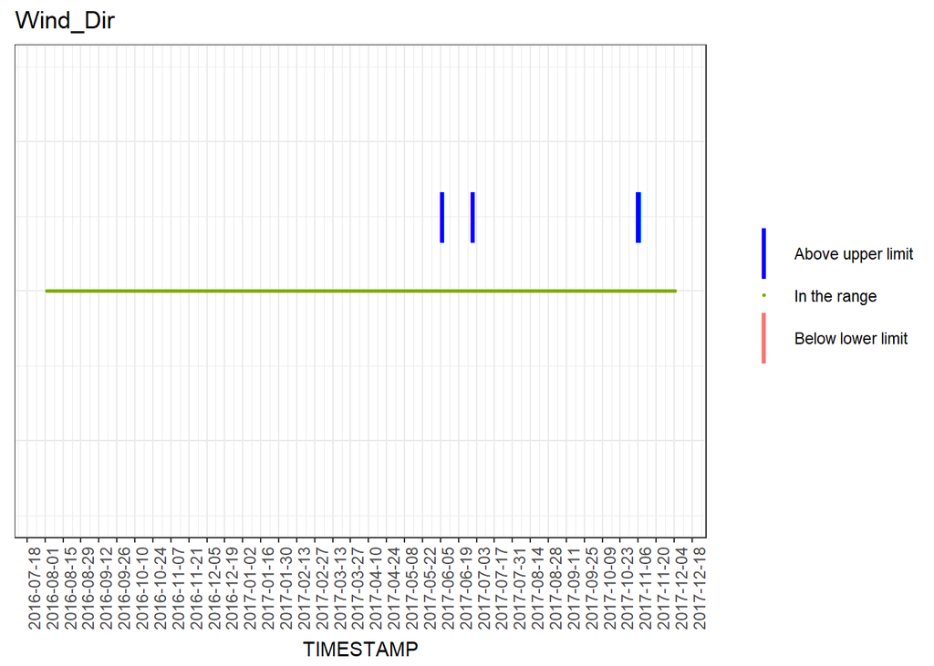

|  | From | To | Number of Record |
| --- | --- | --- | --- |
| Above upper limit | 2017-06-06 06:30:00 | 2017-06-06 06:30:00 | 1 |
| Above upper limit | 2017-06-30 03:00:00 | 2017-06-30 03:00:00 | 1 |
| Above upper limit | 2017-11-05 22:30:00 | 2017-11-06 07:45:00 | 38 |

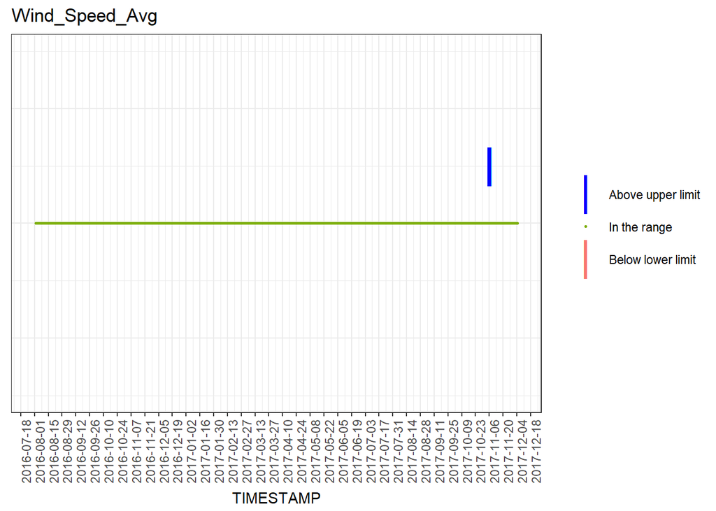

|  | From | To | Number of Record |
| --- | --- | --- | --- |
| Above upper limit | 2017-11-05 18:45:00 | 2017-11-05 18:45:00 | 1 |
| Above upper limit | 2017-11-05 19:15:00 | 2017-11-05 19:15:00 | 1 |
| Above upper limit | 2017-11-05 22:30:00 | 2017-11-06 08:00:00 | 39 |

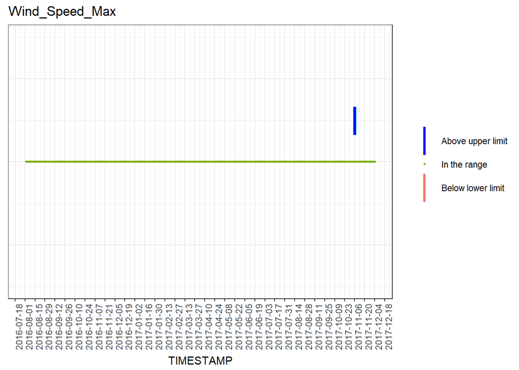

|  | From | To | Number of Record |
| --- | --- | --- | --- |
| Above upper limit | 2017-11-05 18:45:00 | 2017-11-05 18:45:00 | 1 |
| Above upper limit | 2017-11-05 19:15:00 | 2017-11-05 19:15:00 | 1 |
| Above upper limit | 2017-11-05 22:30:00 | 2017-11-06 08:00:00 | 39 |

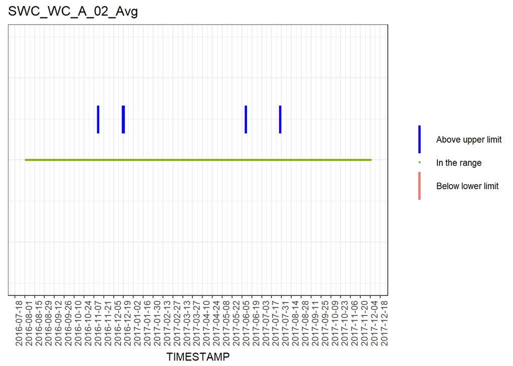

|  | From | To | Number of Record |
| --- | --- | --- | --- |
| Above upper limit | 2016-11-12 23:30:00 | 2016-11-12 23:30:00 | 1 |
| Above upper limit | 2016-12-18 09:30:00 | 2016-12-18 09:30:00 | 1 |
| Above upper limit | 2016-12-19 03:30:00 | 2016-12-19 03:30:00 | 1 |
| Above upper limit | 2017-06-10 10:30:00 | 2017-06-10 10:30:00 | 1 |
| Above upper limit | 2017-07-29 09:30:00 | 2017-07-29 09:30:00 | 1 |

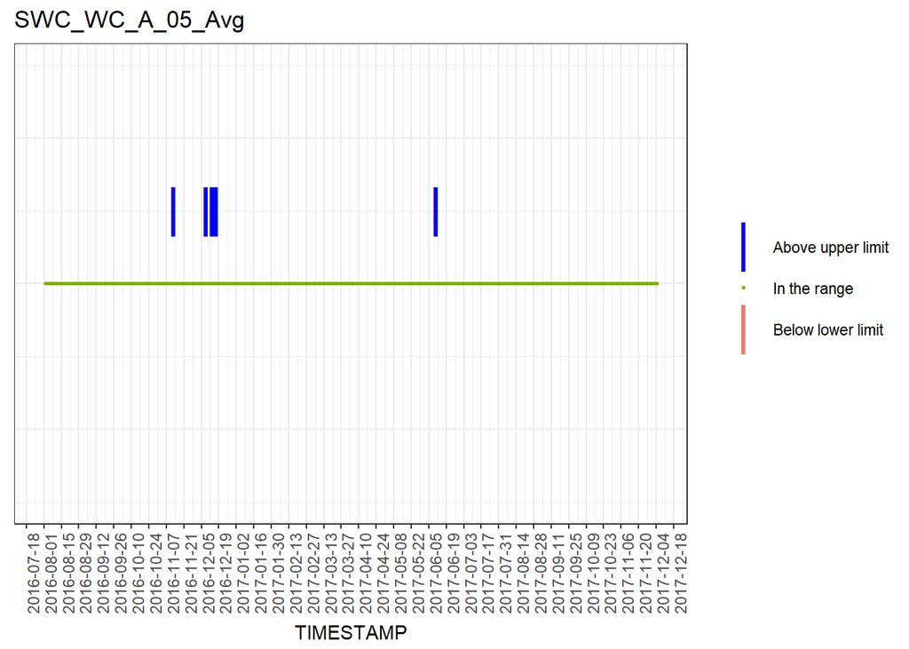

|  | From | To | Number of Record |
| --- | --- | --- | --- |
| Above upper limit | 2016-11-12 16:15:00 | 2016-11-12 16:15:00 | 1 |
| Above upper limit | 2016-12-08 12:15:00 | 2016-12-08 12:15:00 | 1 |
| Above upper limit | 2016-12-13 12:45:00 | 2016-12-13 12:45:00 | 1 |
| Above upper limit | 2016-12-13 20:00:00 | 2016-12-13 20:00:00 | 1 |
| Above upper limit | 2016-12-14 16:30:00 | 2016-12-14 16:30:00 | 1 |
| Above upper limit | 2016-12-16 12:00:00 | 2016-12-16 12:00:00 | 1 |
| Above upper limit | 2017-06-10 12:15:00 | 2017-06-10 12:15:00 | 1 |

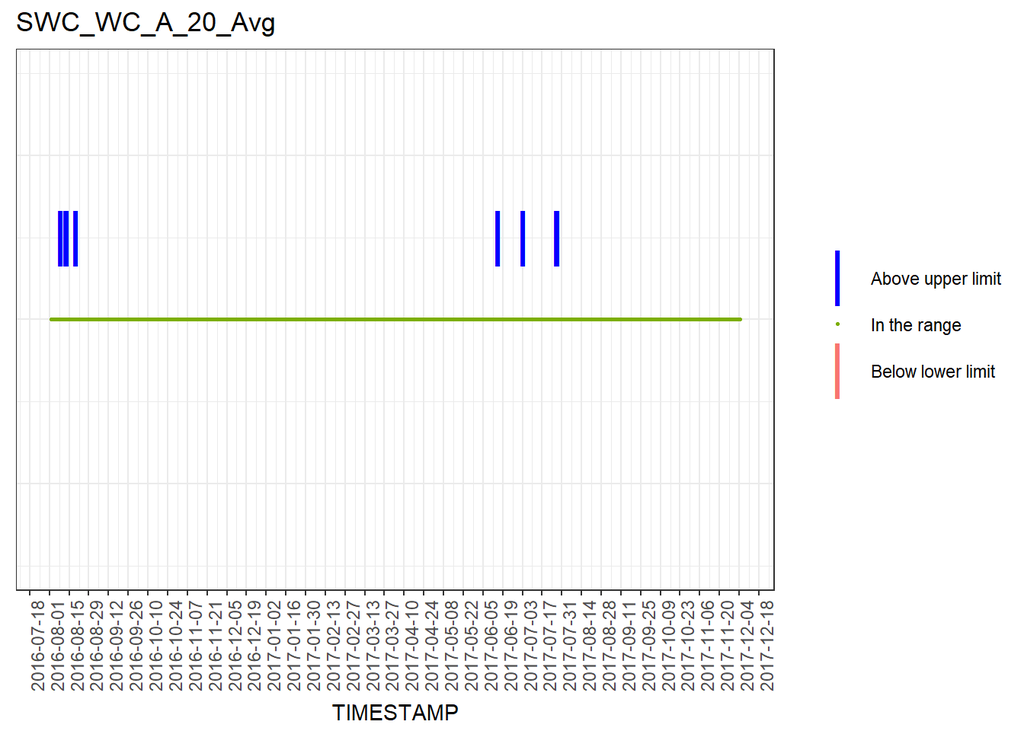

|  | From | To | Number of Record |
| --- | --- | --- | --- |
| Above upper limit | 2016-08-08 16:30:00 | 2016-08-08 16:30:00 | 1 |
| Above upper limit | 2016-08-12 12:00:00 | 2016-08-12 12:00:00 | 1 |
| Above upper limit | 2016-08-12 20:15:00 | 2016-08-12 20:15:00 | 1 |
| Above upper limit | 2016-08-19 15:30:00 | 2016-08-19 15:30:00 | 1 |
| Above upper limit | 2017-06-15 07:15:00 | 2017-06-15 07:15:00 | 1 |
| Above upper limit | 2017-07-03 00:00:00 | 2017-07-03 00:00:00 | 1 |
| Above upper limit | 2017-07-26 23:00:00 | 2017-07-26 23:00:00 | 1 |
| Above upper limit | 2017-07-27 15:30:00 | 2017-07-27 15:30:00 | 1 |

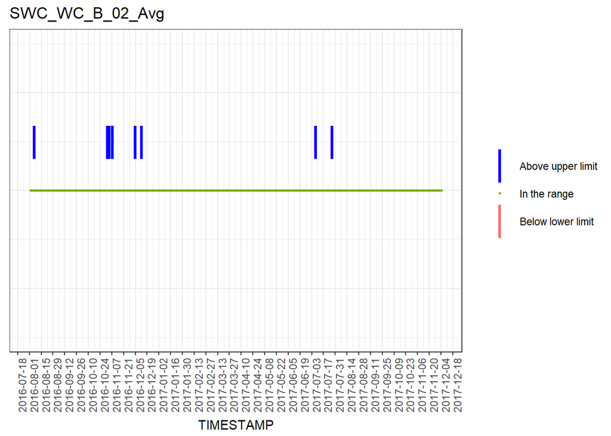

|  | From | To | Number of Record |
| --- | --- | --- | --- |
| Above upper limit | 2016-08-06 15:15:00 | 2016-08-06 15:15:00 | 1 |
| Above upper limit | 2016-11-01 19:45:00 | 2016-11-01 19:45:00 | 1 |
| Above upper limit | 2016-11-02 21:45:00 | 2016-11-02 21:45:00 | 1 |
| Above upper limit | 2016-11-04 02:00:00 | 2016-11-04 02:00:00 | 1 |
| Above upper limit | 2016-11-07 11:45:00 | 2016-11-07 11:45:00 | 1 |
| Above upper limit | 2016-12-04 12:45:00 | 2016-12-04 12:45:00 | 1 |
| Above upper limit | 2016-12-12 10:30:00 | 2016-12-12 10:30:00 | 1 |
| Above upper limit | 2017-07-07 16:00:00 | 2017-07-07 16:00:00 | 1 |
| Above upper limit | 2017-07-26 19:00:00 | 2017-07-26 19:00:00 | 1 |

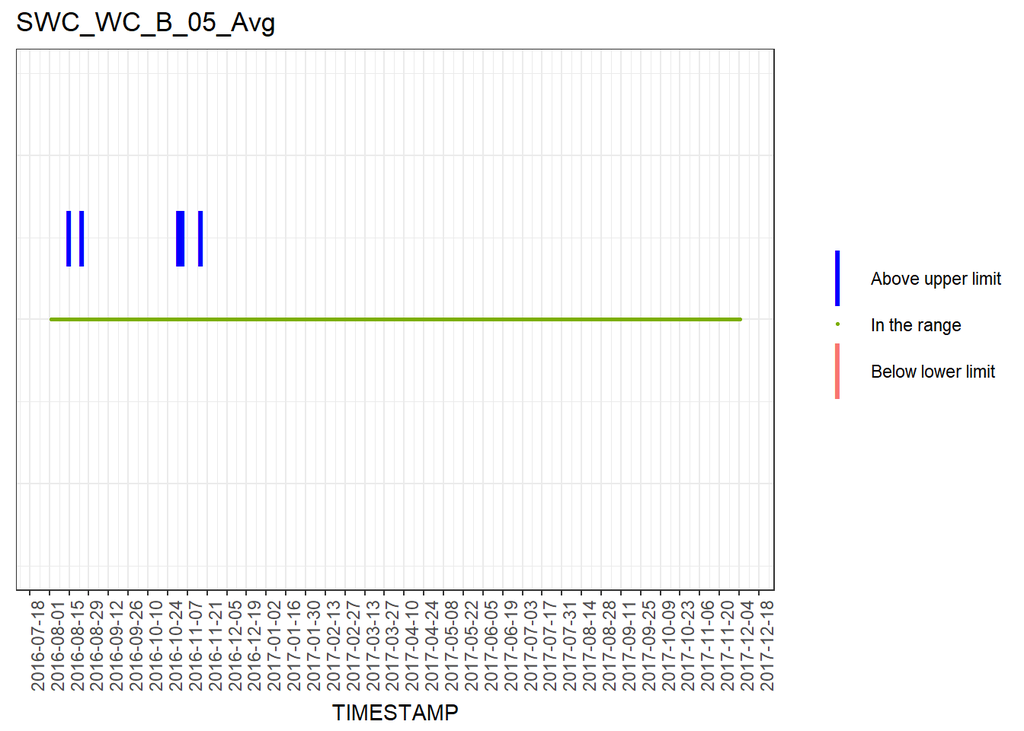

|  | From | To | Number of Record |
| --- | --- | --- | --- |
| Above upper limit | 2016-08-14 17:00:00 | 2016-08-14 17:00:00 | 1 |
| Above upper limit | 2016-08-23 19:15:00 | 2016-08-23 19:15:00 | 1 |
| Above upper limit | 2016-10-31 19:30:00 | 2016-10-31 19:30:00 | 1 |
| Above upper limit | 2016-11-01 14:45:00 | 2016-11-01 14:45:00 | 1 |
| Above upper limit | 2016-11-03 06:00:00 | 2016-11-03 06:00:00 | 1 |
| Above upper limit | 2016-11-16 03:15:00 | 2016-11-16 03:15:00 | 1 |

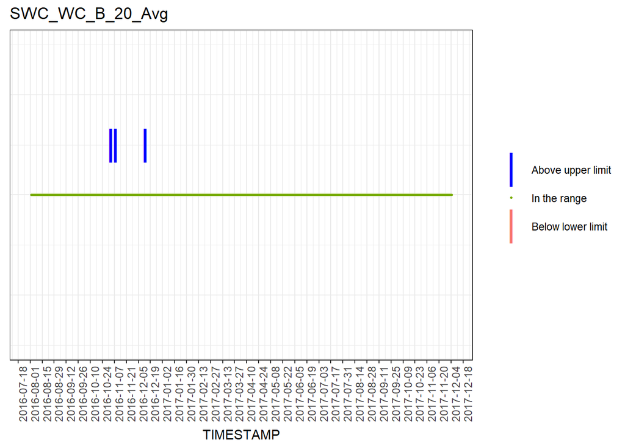

|  | From | To | Number of Record |
| --- | --- | --- | --- |
| Above upper limit | 2016-11-02 16:00:00 | 2016-11-02 16:00:00 | 1 |
| Above upper limit | 2016-11-08 05:30:00 | 2016-11-08 05:30:00 | 1 |
| Above upper limit | 2016-12-12 21:30:00 | 2016-12-12 21:30:00 | 1 |

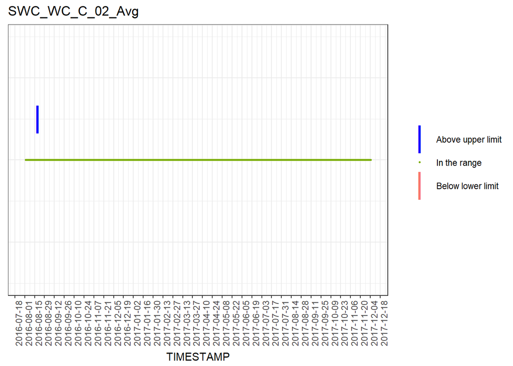

|  | From | To | Number of Record |
| --- | --- | --- | --- |
| Above upper limit | 2016-08-18 23:15:00 | 2016-08-18 23:15:00 | 1 |

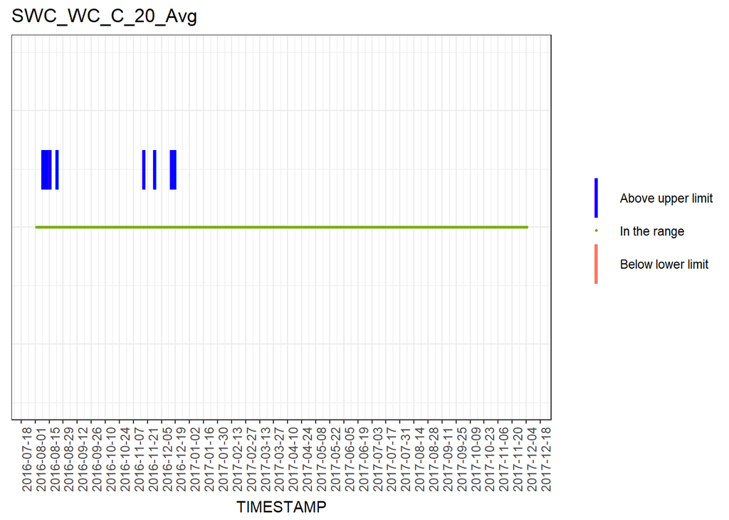

|  | From | To | Number of Record |
| --- | --- | --- | --- |
| Above upper limit | 2016-08-08 11:45:00 | 2016-08-08 11:45:00 | 1 |
| Above upper limit | 2016-08-08 19:15:00 | 2016-08-08 19:15:00 | 1 |
| Above upper limit | 2016-08-09 11:30:00 | 2016-08-09 11:30:00 | 1 |
| Above upper limit | 2016-08-11 14:00:00 | 2016-08-11 14:00:00 | 1 |
| Above upper limit | 2016-08-12 09:15:00 | 2016-08-12 09:15:00 | 1 |
| Above upper limit | 2016-08-15 14:00:00 | 2016-08-15 14:00:00 | 1 |
| Above upper limit | 2016-08-22 15:00:00 | 2016-08-22 15:00:00 | 1 |
| Above upper limit | 2016-11-17 13:45:00 | 2016-11-17 13:45:00 | 1 |
| Above upper limit | 2016-11-28 08:00:00 | 2016-11-28 08:00:00 | 1 |
| Above upper limit | 2016-12-14 23:45:00 | 2016-12-14 23:45:00 | 1 |
| Above upper limit | 2016-12-18 11:15:00 | 2016-12-18 11:15:00 | 1 |

Report end at **2017-12-13 11:54:39**